[figure not shown]

#### Modelos de Regressão para Dados de Contagem com o R

##### [`github.com/leg-ufpr/MRDCr`](https://github.com/leg-ufpr/MRDCr)

# Análise de Contagens com o Modelo COM-Poisson

Walmes M. Zeviani, Eduardo E. Ribeiro Jr & Cesar A. Taconeli

```r
library(MRDCr)
```

# Funções para ajuste dos modelos

## Log-verossimilhança

Implentando a função de log-verossimilhança do modelo COM-Poisson, definida como:

$$\sum_i^n y_i \log(\lambda_i) - \nu \sum_i^n \log(y_i!) -
\sum_i^n \log(Z(\lambda_i, \nu))$$

em que $Z(\lambda_i, \nu) = \sum_{j=0}^\infty \lambda_i^j (j!)^{-\nu}$ e $\lambda_i = \exp(X_i\beta)$

```r
llcmp
```

```
## function (params, y, X, offset = NULL, sumto = ceiling(max(y)^1.5))
## {
##     betas <- params[-1]
##     phi <- params[1]
##     nu <- exp(phi)
##     if (is.null(offset))
##         offset <- 0
##     Xb <- X %*% betas + offset
##     i <- 0:sumto
##     zs <- sapply(Xb, function(loglambda) sum(exp(i * loglambda -
##         nu * lfactorial(i))))
##     Z <- sum(log(zs))
##     ll <- sum(y * Xb - nu * lfactorial(y)) - Z
##     return(-ll)
## }
## <environment: namespace:MRDCr>
```

**Detalhes computacionais**

## Ajuste geral

*Framework* implementado em R que utiliza a forma de escrita de preditores no estilo de fórmulas, similar as funções `lm`, `glm`.

```r
cmp
```

```
## function (formula, data, start = NULL, sumto = NULL, ...)
## {
##     frame <- model.frame(formula, data)
##     terms <- attr(frame, "terms")
##     y <- model.response(frame)
##     X <- model.matrix(terms, frame)
##     off <- model.offset(frame)
##     if (is.null(sumto))
##         sumto <- ceiling(max(y)^1.5)
##     if (is.null(start)) {
##         m0 <- glm.fit(x = X, y = y, offset = off, family = poisson())
##         start <- c(phi = 0, m0$coefficients)
##     }
##     bbmle::parnames(llcmp) <- names(start)
##     model <- bbmle::mle2(llcmp, start = start, data = list(y = y,
##         X = X, offset = off, sumto = sumto), vecpar = TRUE, ...)
##     return(model)
## }
## <environment: namespace:MRDCr>
```

Um exemplo de como são construídas as matrizes, definidos os chutes iniciais e ajustados os modelos na função:

```r
set.seed(2016)
x <- rep(1:3, 2)
t <- rnorm(6, 5)
y <- rpois(6, lambda = x*t)
(da <- data.frame(x, t, y))
```

```
##   x        t  y
## 1 1 4.085258  2
## 2 2 6.001248 16
## 3 3 4.943577 13
## 4 1 5.296645  3
## 5 2 2.208529  5
## 6 3 4.717260  9
```

```r
## Definindo o prditor do modelo
formula <- y ~ x + I(x^2) + offset(log(t))

##-------------------------------------------
## O framework

## Constrói as matrizes para ajuste do modelo
frame <- model.frame(formula, data = da)
(X <- model.matrix(formula, data = da))
```

```
##   (Intercept) x I(x^2)
## 1           1 1      1
## 2           1 2      4
## 3           1 3      9
## 4           1 1      1
## 5           1 2      4
## 6           1 3      9
## attr(,"assign")
## [1] 0 1 2
```

```r
(y <- model.response(frame))
```

```
##  1  2  3  4  5  6
##  2 16 13  3  5  9
```

```r
(o <- model.offset(frame))
```

```
## [1] 1.4073849 1.7919674 1.5980892 1.6670736 0.7923267 1.5512280
```

```r
## Utiliza como valores iniciais as estimativas dos parametros de um
## modelo GLM-Poisson
m0 <- glm.fit(x = X, y = y, offset = o, family = poisson())
start <- c(phi = 0, m0$coefficients)

## Otimiza a função de log-verossimilhança via bbmle
library(bbmle)
parnames(llcmp) <- names(start)
mle2(llcmp, start = start,
     data = list(y = y, X = X, offset = o, sumto = 50),
     vecpar = TRUE)
```

```
##
## Call:
## mle2(minuslogl = llcmp, start = start, data = list(y = y, X = X,
##     offset = o, sumto = 50), vecpar = TRUE)
##
## Coefficients:
##         phi (Intercept)           x      I(x^2)
##   0.3338908  -4.5188932   5.4556688  -1.1173870
##
## Log-likelihood: -11.13
```

# Capulhos de algodão sob efeito de desfolha

```r
data(capdesfo)
str(capdesfo)
```

```
## 'data.frame':    125 obs. of  4 variables:
##  $ est : Factor w/ 5 levels "vegetativo","botão floral",..: 1 1 1 1 1 1 1 1 1 1 ...
##  $ des : num  0 0 0 0 0 0.25 0.25 0.25 0.25 0.25 ...
##  $ rept: int  1 2 3 4 5 1 2 3 4 5 ...
##  $ ncap: int  10 9 8 8 10 11 9 10 10 10 ...
```

```r
## help(capdesfo)
```

Experimento conduzido sob delineamento inteiramente casualizado em casa de vegetação onde avaliou-se o número de capulhos produzidos por plantas de algodão submetidas à níveis de desfolha artificial de remoção foliar em combinação com o estágio fenológico no qual a desfolha foi aplicada.

- `est`: Estágio fenológico com cinco níveis (vegetativo, botão floral, florecimento, maça, capulho);
- `des`: Nível de desfolha artificial de remoção foliar (0, 25, 50, 75, 100%);
- `ncap`: Número de capulhos de algodão produzidos ao final da ciclo cultura.

## Análise Exploratória

```r
## Experimento balanceado
xtabs(~est + des, data = capdesfo)
```

```
##               des
## est            0 0.25 0.5 0.75 1
##   vegetativo   5    5   5    5 5
##   botão floral 5    5   5    5 5
##   florecimento 5    5   5    5 5
##   maça         5    5   5    5 5
##   capulho      5    5   5    5 5
```

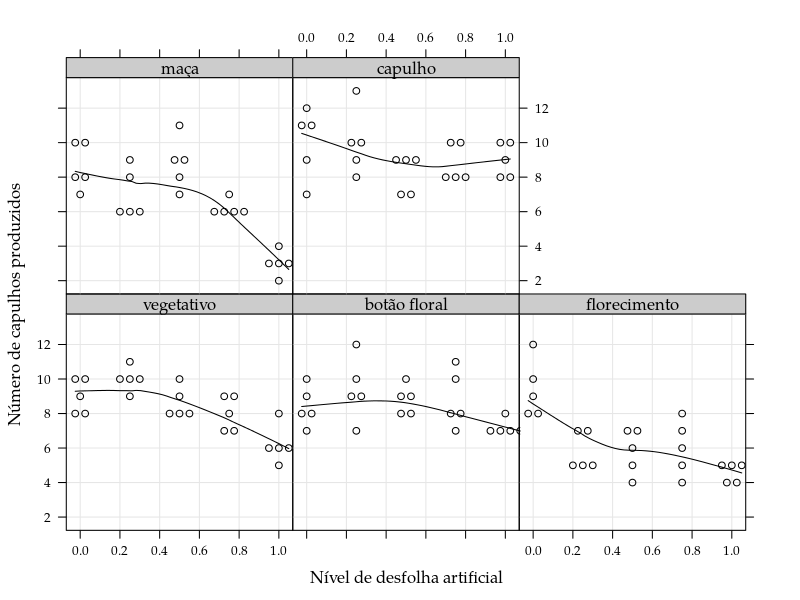

```r
library(lattice)
library(latticeExtra)

(xy <- xyplot(ncap ~ des | est,
             data = capdesfo,
             xlab = "Nível de desfolha artificial",
             ylab = "Número de capulhos produzidos",
             type = c("p", "g", "smooth"),
             panel = panel.beeswarm,
             r = 0.05))
```

```r
## Avaliando preliminarmente suposição de equidispersão
(mv <- aggregate(ncap ~ est + des, data = capdesfo,
                 FUN = function(x) c(mean = mean(x), var = var(x))))
```

```
##             est  des ncap.mean ncap.var
## 1    vegetativo 0.00       9.0      1.0
## 2  botão floral 0.00       8.4      1.3
## 3  florecimento 0.00       9.4      2.8
## 4          maça 0.00       8.6      1.8
## 5       capulho 0.00      10.0      4.0
## 6    vegetativo 0.25      10.0      0.5
## 7  botão floral 0.25       9.4      3.3
## 8  florecimento 0.25       5.8      1.2
## 9          maça 0.25       7.0      2.0
## 10      capulho 0.25      10.0      3.5
## 11   vegetativo 0.50       8.6      0.8
## 12 botão floral 0.50       8.8      0.7
## 13 florecimento 0.50       5.8      1.7
## 14         maça 0.50       8.8      2.2
## 15      capulho 0.50       8.2      1.2
## 16   vegetativo 0.75       8.0      1.0
## 17 botão floral 0.75       8.8      2.7
## 18 florecimento 0.75       6.0      2.5
## 19         maça 0.75       6.2      0.2
## 20      capulho 0.75       8.8      1.2
## 21   vegetativo 1.00       6.2      1.2
## 22 botão floral 1.00       7.2      0.2
## 23 florecimento 1.00       4.6      0.3
## 24         maça 1.00       3.0      0.5
## 25      capulho 1.00       9.0      1.0
```

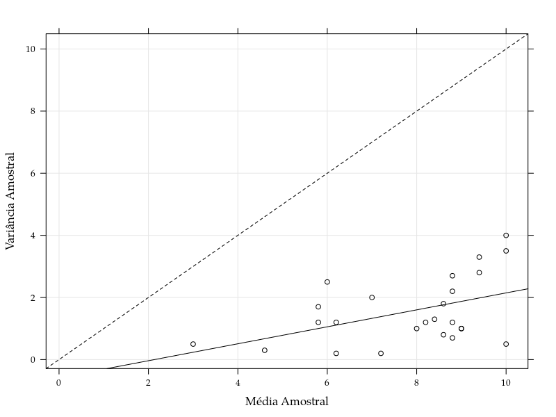

```r
xlim <- ylim <- extendrange(c(mv$ncap), f = 0.05)
xyplot(ncap[, "var"] ~ ncap[, "mean"],
       data = mv,
       xlim = xlim,
       ylim = ylim,
       ylab = "Variância Amostral",
       xlab = "Média Amostral",
       panel = function(x, y) {
           panel.xyplot(x, y, type = c("p", "r"), grid = TRUE)
           panel.abline(a = 0, b = 1, lty = 2)
       })
```

## Ajuste dos modelos

```r
## Preditores considerados
f1 <- ncap ~ 1
f2 <- ncap ~ des + I(des^2)
f3 <- ncap ~ est:des + I(des^2)
f4 <- ncap ~ est:(des + I(des^2))

## Ajustando os modelos Poisson
m1P <- glm(f1, data = capdesfo, family = poisson)
m2P <- glm(f2, data = capdesfo, family = poisson)
m3P <- glm(f3, data = capdesfo, family = poisson)
m4P <- glm(f4, data = capdesfo, family = poisson)

## Ajustando os modelos COM-Poisson
m1C <- cmp(f1, data = capdesfo)
m2C <- cmp(f2, data = capdesfo)
m3C <- cmp(f3, data = capdesfo)
m4C <- cmp(f4, data = capdesfo)
```

## Comparação dos ajustes

```r
## Verossimilhancas dos modelos ajustados
cbind("Poisson" = sapply(list(m1P, m2P, m3P, m4P), logLik),
      "COM-Poisson" = sapply(list(m1C, m2C, m3C, m4C), logLik))
```

```
##        Poisson COM-Poisson
## [1,] -279.9328   -272.4794
## [2,] -271.3543   -256.0893
## [3,] -258.6741   -220.1977
## [4,] -255.8031   -208.2500
```

```r
## Teste de razão de verossimilhanças
anova(m1P, m2P, m3P, m4P, test = "Chisq")
```

```
## Analysis of Deviance Table
##
## Model 1: ncap ~ 1
## Model 2: ncap ~ des + I(des^2)
## Model 3: ncap ~ est:des + I(des^2)
## Model 4: ncap ~ est:(des + I(des^2))
##   Resid. Df Resid. Dev Df Deviance  Pr(>Chi)
## 1       124     75.514
## 2       122     58.357  2   17.157 0.0001881 ***
## 3       118     32.997  4   25.360 4.258e-05 ***
## 4       114     27.255  4    5.742 0.2192611
## ---
## Signif. codes:  0 '***' 0.001 '**' 0.01 '*' 0.05 '.' 0.1 ' ' 1
```

```r
anova(m1C, m2C, m3C, m4C)
```

```
## Likelihood Ratio Tests
## Model 1: m1C, [llcmp]: phi+(Intercept)
## Model 2: m2C, [llcmp]: phi+(Intercept)+des+I(des^2)
## Model 3: m3C, [llcmp]: phi+(Intercept)+I(des^2)+
##           estvegetativo:des+estbotão floral:des+
##           estflorecimento:des+estmaça:des+estcapulho:des
## Model 4: m4C, [llcmp]: phi+(Intercept)+estvegetativo:des+
##           estbotão floral:des+estflorecimento:des+estmaça:des+
##           estcapulho:des+estvegetativo:I(des^2)+estbotão
##           floral:I(des^2)+estflorecimento:I(des^2)+
##           estmaça:I(des^2)+estcapulho:I(des^2)
##   Tot Df Deviance  Chisq Df Pr(>Chisq)
## 1      2   544.96
## 2      4   512.18 32.780  2  7.619e-08 ***
## 3      8   440.40 71.783  4  9.537e-15 ***
## 4     12   416.50 23.895  4  8.382e-05 ***
## ---
## Signif. codes:  0 '***' 0.001 '**' 0.01 '*' 0.05 '.' 0.1 ' ' 1
```

```r
## Estimativas dos parâmetros
summary(m4P)
```

```
##
## Call:
## glm(formula = f4, family = poisson, data = capdesfo)
##
## Deviance Residuals:
##      Min        1Q    Median        3Q       Max
## -1.06976  -0.31729  -0.02347   0.34779   1.27069
##
## Coefficients:
##                           Estimate Std. Error z value Pr(>|z|)
## (Intercept)               2.189560   0.063333  34.572   <2e-16 ***
## estvegetativo:des         0.436859   0.515560   0.847   0.3968
## estbotão floral:des       0.289715   0.507751   0.571   0.5683
## estflorecimento:des      -1.242481   0.603706  -2.058   0.0396 *
## estmaça:des               0.364871   0.565803   0.645   0.5190
## estcapulho:des            0.008949   0.503760   0.018   0.9858
## estvegetativo:I(des^2)   -0.805215   0.583915  -1.379   0.1679
## estbotão floral:I(des^2) -0.487850   0.566394  -0.861   0.3891
## estflorecimento:I(des^2)  0.672837   0.680195   0.989   0.3226
## estmaça:I(des^2)         -1.310346   0.672780  -1.948   0.0515 .
## estcapulho:I(des^2)      -0.019970   0.552505  -0.036   0.9712
## ---
## Signif. codes:  0 '***' 0.001 '**' 0.01 '*' 0.05 '.' 0.1 ' ' 1
##
## (Dispersion parameter for poisson family taken to be 1)
##
##     Null deviance: 75.514  on 124  degrees of freedom
## Residual deviance: 27.255  on 114  degrees of freedom
## AIC: 533.61
##
## Number of Fisher Scoring iterations: 4
```

```r
summary(m4C)
```

```
## Maximum likelihood estimation
##
## Call:
## bbmle::mle2(minuslogl = llcmp, start = start, data = list(y = y,
##     X = X, offset = off, sumto = sumto), vecpar = TRUE)
##
## Coefficients:
##                           Estimate Std. Error z value     Pr(z)
## phi                       1.584744   0.127631 12.4166 < 2.2e-16 ***
## (Intercept)              10.896662   1.404311  7.7594 8.531e-15 ***
## estvegetativo:des         2.018744   1.140780  1.7696 0.0767909 .
## estbotão floral:des       1.343071   1.109168  1.2109 0.2259408
## estflorecimento:des      -5.750451   1.479861 -3.8858 0.0001020 ***
## estmaça:des               1.594963   1.229254  1.2975 0.1944575
## estcapulho:des            0.037655   1.088012  0.0346 0.9723918
## estvegetativo:I(des^2)   -3.724525   1.341954 -2.7754 0.0055125 **
## estbotão floral:I(des^2) -2.264721   1.254650 -1.8051 0.0710650 .
## estflorecimento:I(des^2)  3.134664   1.504387  2.0837 0.0371891 *
## estmaça:I(des^2)         -5.894333   1.611937 -3.6567 0.0002555 ***
## estcapulho:I(des^2)      -0.090110   1.193331 -0.0755 0.9398080
## ---
## Signif. codes:  0 '***' 0.001 '**' 0.01 '*' 0.05 '.' 0.1 ' ' 1
##
## -2 log L: 416.4999
```

## Avaliando modelo proposto

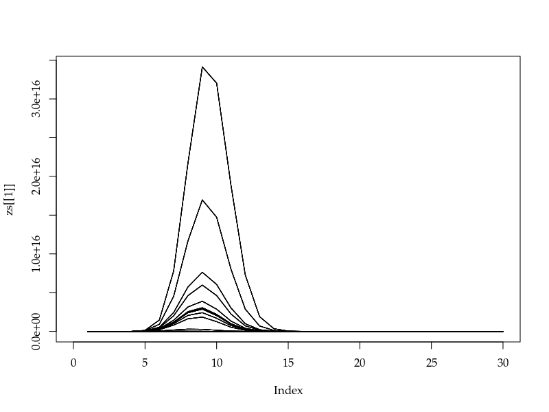

```r
## Um dos problemas computacionais do modelo COM-Poisson é a obtenção da
## constante de normalização Z. Assim uma visualização pós ajuste para
## verificar se o ajuste proporcionou uma densidade válida se faz
## necessária
convergencez(m4C)
```

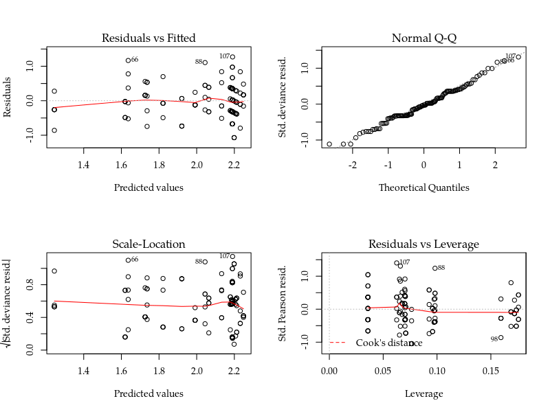

```r
## Dado que o modelo COM-Poisson leva as mesmas estimativas pontuais que
## o modelo Poisson a análise de diagnóstico padrão pode ser utilizada
par(mfrow = c(2, 2))
plot(m4P)
```

```r
##-------------------------------------------
## Testando a nulidade do parâmetro phi

## Usando o ajuste Poisson
trv <- 2 * (logLik(m4C) - logLik(m4P))
attributes(trv) <- NULL
round(c(trv, pchisq(trv, 1, lower = FALSE)), digits = 5)
```

```
## [1] 95.10632  0.00000
```

```r
## Reajustando o COM-Poisson para phi = 0 (ou equivalente nu = 1)
m4Cfixed <- cmp(f4, data = capdesfo, fixed = list("phi" = 0))
anova(m4C, m4Cfixed)
```

```
## Likelihood Ratio Tests
## Model 1: m4C, [llcmp]: phi+(Intercept)+estvegetativo:des+
##           estbotão floral:des+estflorecimento:des+estmaça:des+
##           estcapulho:des+estvegetativo:I(des^2)+estbotão
##           floral:I(des^2)+estflorecimento:I(des^2)+
##           estmaça:I(des^2)+estcapulho:I(des^2)
## Model 2: m4Cfixed, [llcmp]: (Intercept)+estvegetativo:des+
##           estbotão floral:des+estflorecimento:des+estmaça:des+
##           estcapulho:des+estvegetativo:I(des^2)+estbotão
##           floral:I(des^2)+estflorecimento:I(des^2)+
##           estmaça:I(des^2)+estcapulho:I(des^2)
##   Tot Df Deviance  Chisq Df Pr(>Chisq)
## 1     12   416.50
## 2     11   511.61 95.106  1  < 2.2e-16 ***
## ---
## Signif. codes:  0 '***' 0.001 '**' 0.01 '*' 0.05 '.' 0.1 ' ' 1
```

```r
## Via perfil de log-verossimilhança
perf <- profile(m4C, which = 1)
confint(perf)
```

```
##    2.5 %   97.5 %
## 1.323326 1.824516
```

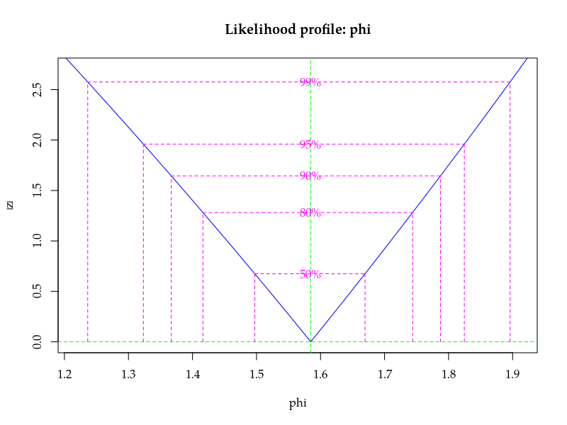

```r
plot(perf)
```

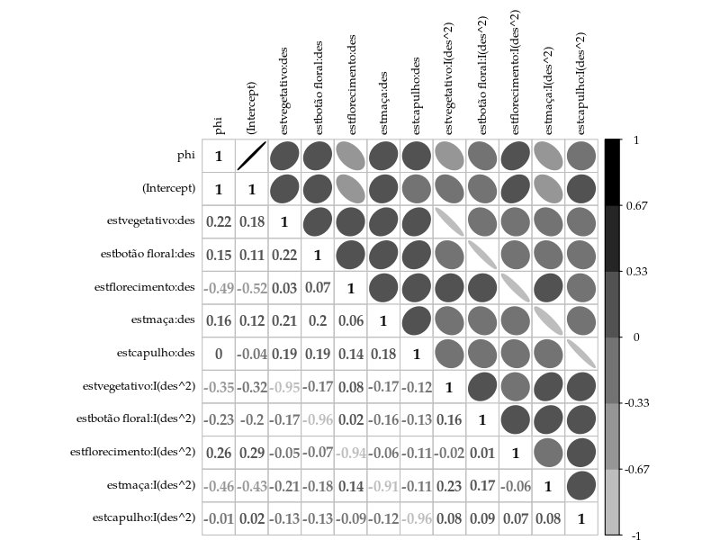

```r
##-------------------------------------------
## Verificando a matriz ve variâncias e covariâncias
Vcov <- vcov(m4C)
Corr <- cov2cor(Vcov)

library(corrplot)
corrplot.mixed(Corr, lower = "number", upper = "ellipse",
               diag = "l", tl.pos = "lt", tl.col = "black",
               tl.cex = 0.8, col = brewer.pal(9, "Greys")[-(1:3)])
```

## Predição

```r
## Predição pontual
pred <- with(capdesfo,
             expand.grid(
                 est = levels(est),
                 des = seq(min(des), max(des), l = 20)
             ))

##-------------------------------------------
## Considerando a Poisson
mediasP <- exp(predict(m4P, newdata = pred))
aux <- data.frame(modelo = "Poisson", fit = mediasP)
predP <- cbind(pred, aux)

##-------------------------------------------
## Considerando a COM-Poisson
f4; f4[[2]] <- NULL; f4
```

```
## ncap ~ est:(des + I(des^2))
```

```
## ~est:(des + I(des^2))
```

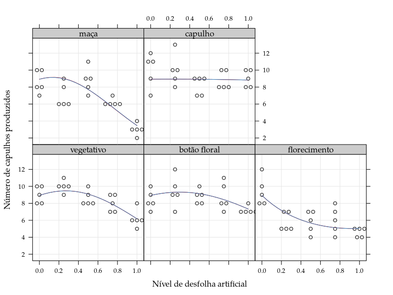

```r
X <- model.matrix(f4, data = pred)

## Obtendo os parâmetros da distribuição (lambdas e phi)
betas <- coef(m4C)[-1]
phi <- coef(m4C)[1]
loglambdas <- X %*% betas

## Aplicando a "inversa da função de ligação", ou seja, obtendo as
## contagens médias
mediasC <- sapply(loglambdas, FUN = function(p) {
    y <- 0:50; py <- dcmp(y, p, phi, sumto = 100)
    sum(y*py)
})
aux <- data.frame(modelo = "COM-Poisson", fit = mediasC)
predC <- cbind(pred, aux)

##-------------------------------------------
## Visualizando os valores preditos pelos dois modelos
da <- rbind(predP, predC)

update(xy, type = c("p", "g")) +
    as.layer(xyplot(fit ~ des | est,
                    groups = modelo,
                    data = da, type = "l"))
```

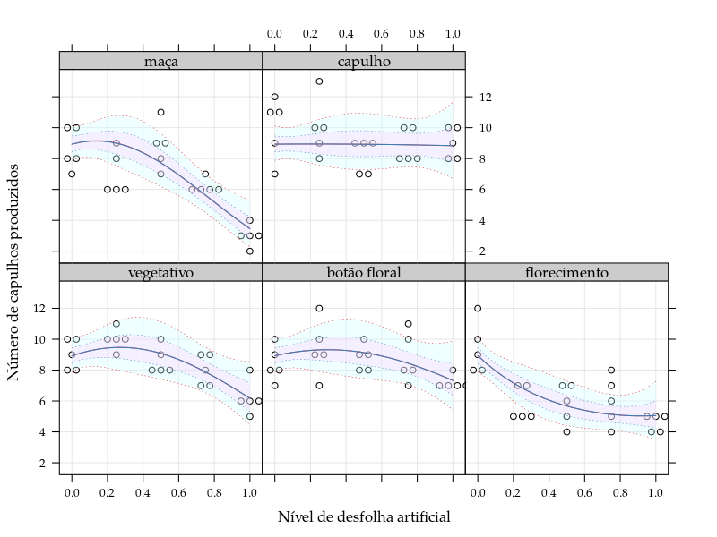

```r
## Predição intervalar
qn <- qnorm(0.975) * c(lwr = -1, upr = 1)

##-------------------------------------------
## Considerando a Poisson
aux <- predict(m4P, newdata = pred, se.fit = TRUE)
aux <- with(aux, exp(fit + outer(se.fit, qn, FUN = "*")))
predP <- cbind(predP, aux)

##-------------------------------------------
## Considerando a COM-Poisson

## Obtendo os erros padrão das estimativas
##   Obs.: Deve-se usar a matriz de variâncias e covariâncias
##   condicional, pois os parâmetros de locação (betas) e dispersão
##   (phi) não são ortogonais.
Vc <- Vcov[-1, -1] - Vcov[-1, 1] %*% solve(Vcov[1, 1]) %*% Vcov[1, -1]
U <- chol(Vc)
se <- sqrt(apply(X %*% t(U), MARGIN = 1, FUN = function(x) {
    sum(x^2)
}))

aux <- c(loglambdas) + outer(se, qn, FUN = "*")
aux <- apply(aux, MARGIN = 2,
             FUN = function(col) {
                 sapply(col, FUN = function(p) {
                     y <- 0:50; py <- dcmp(y, p, phi, sumto = 100)
                     sum(y*py)
                 })
             })
predC <- cbind(predC, aux)

##-------------------------------------------
## Visualizando os valores preditos intervalares pelos dois modelos
da <- rbind(predP, predC)

update(xy, type = c("p", "g")) +
    as.layer(xyplot(fit ~ des | est,
                    groups = modelo,
                    data = da,
                    type = "l",
                    ly = da$lwr,
                    uy = da$upr,
                    cty = "bands",
                    alpha = 0.3,
                    prepanel = prepanel.cbH,
                    panel.groups = panel.cbH,
                    panel = panel.superpose))
```

# Capulhos de algodão sob exposição à mosca-branca

```r
data(capmosca)
str(capmosca)
```

```
## 'data.frame':    60 obs. of  8 variables:
##  $ dexp   : int  0 0 0 0 0 0 0 0 0 0 ...
##  $ vaso   : Factor w/ 5 levels "1","2","3","4",..: 1 1 2 2 3 3 4 4 5 5 ...
##  $ planta : Factor w/ 2 levels "1","2": 1 2 1 2 1 2 1 2 1 2 ...
##  $ alt    : num  70.5 67.5 72 70 64 64.5 67.5 61 70 70 ...
##  $ pesocap: num  25.2 NA 28.5 NA 31.8 ...
##  $ nerep  : int  4 4 3 5 5 5 5 5 4 5 ...
##  $ ncap   : int  4 4 2 5 5 5 5 5 4 5 ...
##  $ nnos   : int  13 14 14 15 15 11 14 11 14 15 ...
```

```r
## help(capmosca)
```

Experimento conduzido sob delineamento inteiramente casualizado na Universidade Federal da Grande Dourados, cujo objetivo foi avaliar os impactos da exposição de plantas de algodão à alta infestação da praga mosca-branca. No experimento avaliou-se duas plantas por vaso, nesta análise tomaremos como unidade amostral o vaso e o interesse será somente na variável número de capulhos produzidos.

```r
capmosca <- aggregate(ncap ~ vaso + dexp, data = capmosca, FUN = sum)
str(capmosca)
```

```
## 'data.frame':    30 obs. of  3 variables:
##  $ vaso: Factor w/ 5 levels "1","2","3","4",..: 1 2 3 4 5 1 2 3 4 5 ...
##  $ dexp: int  0 0 0 0 0 1 1 1 1 1 ...
##  $ ncap: int  8 7 10 10 9 5 7 8 8 11 ...
```

Assim as variáveis consideradas são definidas como:

- `dexp`: Dias de exposição à alta infestação de mosca-branca;
- `ncap`: Número de capulhos de algodão produzidos ao final do experimento.

## Análise Exploratória

```r
## Experimento balanceado
xtabs(~dexp, data = capmosca)
```

```
## dexp
## 0 1 2 3 4 5
## 5 5 5 5 5 5
```

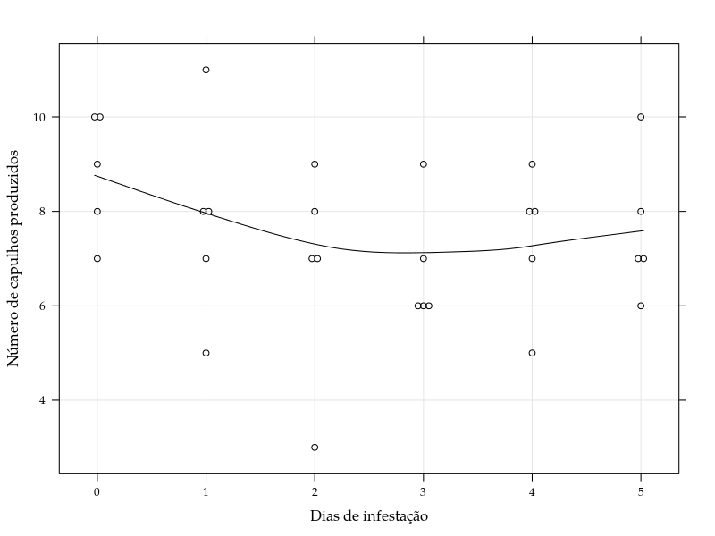

```r
(xy <- xyplot(ncap ~ dexp,
              data = capmosca,
              xlab = "Dias de infestação",
              ylab = "Número de capulhos produzidos",
              type = c("p", "g", "smooth"),
              panel = panel.beeswarm,
              r = 0.05))
```

```r
## Avaliando preliminarmente suposição de equidispersão
(mv <- aggregate(ncap ~ dexp, data = capmosca,
                 FUN = function(x) c(mean = mean(x), var = var(x))))
```

```
##   dexp ncap.mean ncap.var
## 1    0       8.8      1.7
## 2    1       7.8      4.7
## 3    2       6.8      5.2
## 4    3       6.8      1.7
## 5    4       7.4      2.3
## 6    5       7.6      2.3
```

## Ajuste dos modelos

```r
## Preditores considerados
f1 <- ncap ~ 1
f2 <- ncap ~ dexp
f3 <- ncap ~ dexp + I(dexp^2)

## Ajustando os modelos Poisson
m1P <- glm(f1, data = capmosca, family = poisson)
m2P <- glm(f2, data = capmosca, family = poisson)
m3P <- glm(f3, data = capmosca, family = poisson)

## Ajustando os modelos COM-Poisson
m1C <- cmp(f1, data = capmosca)
m2C <- cmp(f2, data = capmosca)
m3C <- cmp(f3, data = capmosca)
```

## Comparação dos ajustes

```r
## Verossimilhancas dos modelos ajustados
cbind("Poisson" = sapply(list(m1P, m2P, m3P), logLik),
      "COM-Poisson" = sapply(list(m1C, m2C, m3C), logLik))
```

```
##        Poisson COM-Poisson
## [1,] -63.76981   -58.77209
## [2,] -63.52399   -58.13540
## [3,] -62.93611   -56.49274
```

```r
## Teste de razão de verossimilhanças
anova(m1P, m2P, m3P, test = "Chisq")
```

```
## Analysis of Deviance Table
##
## Model 1: ncap ~ 1
## Model 2: ncap ~ dexp
## Model 3: ncap ~ dexp + I(dexp^2)
##   Resid. Df Resid. Dev Df Deviance Pr(>Chi)
## 1        29     11.993
## 2        28     11.501  1  0.49164   0.4832
## 3        27     10.325  1  1.17575   0.2782
```

```r
anova(m1C, m2C, m3C)
```

```
## Likelihood Ratio Tests
## Model 1: m1C, [llcmp]: phi+(Intercept)
## Model 2: m2C, [llcmp]: phi+(Intercept)+dexp
## Model 3: m3C, [llcmp]: phi+(Intercept)+dexp+I(dexp^2)
##   Tot Df Deviance  Chisq Df Pr(>Chisq)
## 1      2   117.54
## 2      3   116.27 1.2734  1     0.2591
## 3      4   112.98 3.2853  1     0.0699 .
## ---
## Signif. codes:  0 '***' 0.001 '**' 0.01 '*' 0.05 '.' 0.1 ' ' 1
```

```r
## Estimativas dos parâmetros
summary(m3P)
```

```
##
## Call:
## glm(formula = f3, family = poisson, data = capmosca)
##
## Deviance Residuals:
##      Min        1Q    Median        3Q       Max
## -1.72211  -0.32208   0.01768   0.34877   1.13445
##
## Coefficients:
##             Estimate Std. Error z value Pr(>|z|)
## (Intercept)  2.17571    0.13842  15.718   <2e-16 ***
## dexp        -0.16923    0.13586  -1.246    0.213
## I(dexp^2)    0.02870    0.02638   1.088    0.277
## ---
## Signif. codes:  0 '***' 0.001 '**' 0.01 '*' 0.05 '.' 0.1 ' ' 1
##
## (Dispersion parameter for poisson family taken to be 1)
##
##     Null deviance: 11.993  on 29  degrees of freedom
## Residual deviance: 10.325  on 27  degrees of freedom
## AIC: 131.87
##
## Number of Fisher Scoring iterations: 4
```

```r
summary(m3C)
```

```
## Maximum likelihood estimation
##
## Call:
## bbmle::mle2(minuslogl = llcmp, start = start, data = list(y = y,
##     X = X, offset = off, sumto = sumto), vecpar = TRUE)
##
## Coefficients:
##              Estimate Std. Error z value     Pr(z)
## phi          1.125858   0.261906  4.2987 1.718e-05 ***
## (Intercept)  6.824427   1.817389  3.7551 0.0001733 ***
## dexp        -0.499138   0.266245 -1.8747 0.0608297 .
## I(dexp^2)    0.084627   0.050231  1.6848 0.0920312 .
## ---
## Signif. codes:  0 '***' 0.001 '**' 0.01 '*' 0.05 '.' 0.1 ' ' 1
##
## -2 log L: 112.9855
```

## Avaliando modelo proposto

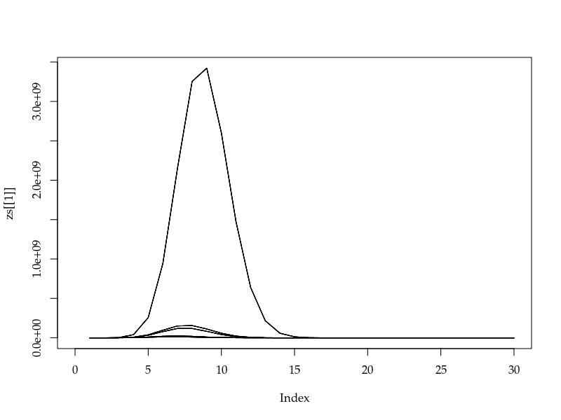

```r
## Um dos problemas computacionais do modelo COM-Poisson é a obtenção da
## constante de normalização Z. Assim uma visualização pós ajuste para
## verificar se o ajuste proporcionou uma densidade válida se faz
## necessária
convergencez(m3C)
```

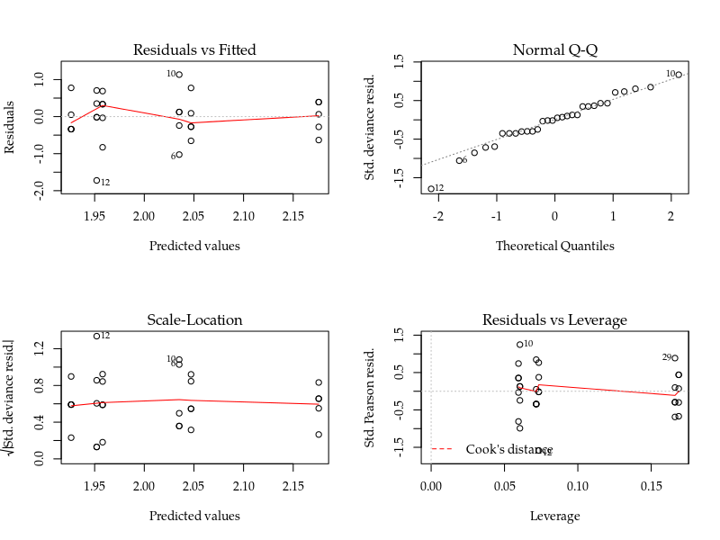

```r
## Dado que o modelo COM-Poisson leva as mesmas estimativas pontuais que
## o modelo Poisson a análise de diagnóstico padrão pode ser utilizada
par(mfrow = c(2, 2))
plot(m3P)
```

```r
##-------------------------------------------
## Testando a nulidade do parâmetro phi

## Usando o ajuste Poisson
trv <- 2 * (logLik(m3C) - logLik(m3P))
attributes(trv) <- NULL
round(c(trv, pchisq(trv, 1, lower = FALSE)), digits = 5)
```

```
## [1] 12.88675  0.00033
```

```r
## Reajustando o COM-Poisson para phi = 0 (ou equivalente nu = 1)
m3Cfixed <- cmp(f3, data = capmosca, fixed = list("phi" = 0))
anova(m3C, m3Cfixed)
```

```
## Likelihood Ratio Tests
## Model 1: m3C, [llcmp]: phi+(Intercept)+dexp+I(dexp^2)
## Model 2: m3Cfixed, [llcmp]: (Intercept)+dexp+I(dexp^2)
##   Tot Df Deviance  Chisq Df Pr(>Chisq)
## 1      4   112.98
## 2      3   125.87 12.887  1  0.0003309 ***
## ---
## Signif. codes:  0 '***' 0.001 '**' 0.01 '*' 0.05 '.' 0.1 ' ' 1
```

```r
## Via perfil de log-verossimilhança
perf <- profile(m3C, which = 1)
confint(perf)
```

```
##     2.5 %    97.5 %
## 0.5622126 1.5977357
```

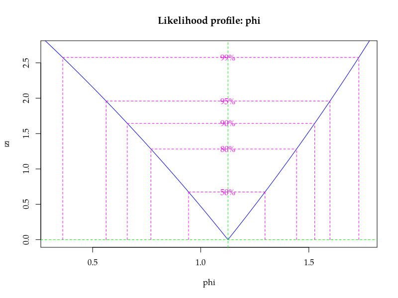

```r
plot(perf)
```

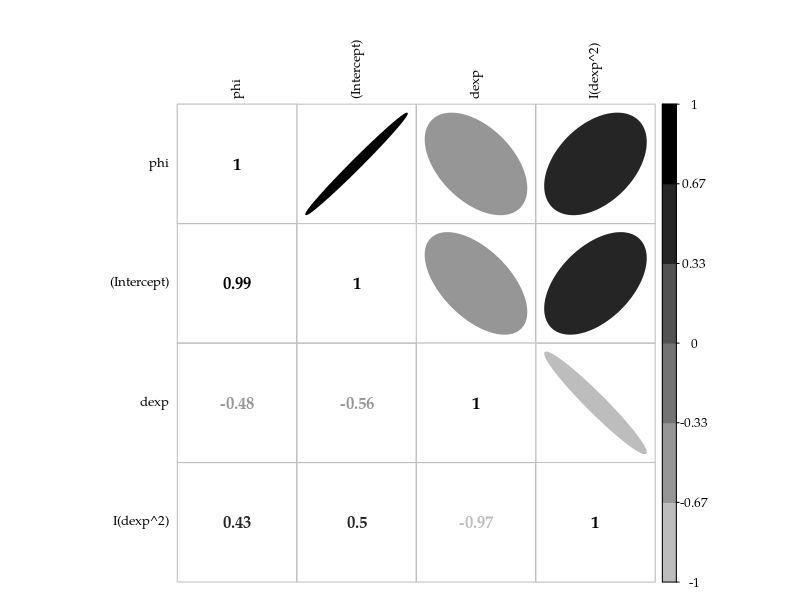

```r
##-------------------------------------------
## Verificando a matriz ve variâncias e covariâncias
Vcov <- vcov(m3C)
Corr <- cov2cor(Vcov)

library(corrplot)
corrplot.mixed(Corr, lower = "number", upper = "ellipse",
               diag = "l", tl.pos = "lt", tl.col = "black",
               tl.cex = 0.8, col = brewer.pal(9, "Greys")[-(1:3)])
```